# MLTA - Code for Gollini, I. (in press) - *A mixture model approach for clustering bipartite networks*

Isabella Gollini

12/06/2019

This code accompany the paper Gollini, I. (in press) “A mixture model approach for clustering bipartite networks”, Challenges in Social Network Research Volume in the *Lecture Notes in Social Networks* (LNSN - Series of Springer). Preprint: [arXiv:1905.02659](http://arxiv.org/abs/1905.02659).

```r
set.seed(123)
```

Load the `noordin` dataset which is available in the `manet` package.

```r
data(noordin, package = "manet")
```

Load the `lvm4net` package and set the incidence matrix in the correct format, and give names to the sender nodes.

```r
library(lvm4net)
X <- as.matrix(noordin)
namesX <- paste('V', seq(1, nrow(X)))
```

Heatmap of the data:

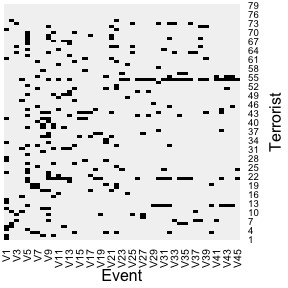

```r
heatmap(
  X,
  Rowv = NA,
  Colv = NA,
  col = grey(c(0.95, 0.0)),
  scale = "none",
  margins = c(3, 3),
  xlab = "Event",
  ylab = "Terrorist"
  )
```

We want to fit the model on a range of groups `G`, from 2 to 4 and the latent continuous latent variable takes value `D` from 0 to 3.

```r
G <- 2:4 # is the number of groups
D <- 0:3 # is the dimension of the latent variable
```

Fit the `mlta`

```r
mod.mlta <- mlta(X, G = G, D = D, wfix = FALSE) # It takes ~ 2 minutes with 3 starts
```

```r
mod.mlta.wfix <- mlta(X, G = G, D = 1:3, wfix = TRUE) # It takes ~ 2 minutes with 3 starts
```

```r
mod.mlta$BIC$`Table of BIC Results`
```

```
##              G=2      G=3      G=4
## dim y=0 2087.159 2187.163 2305.239
## dim y=1 2165.918 2412.358 2732.959
## dim y=2 2402.889 2885.561 3412.363
## dim y=3 2792.768 3409.382 4154.685
```

```r
mod.mlta.wfix$BIC$`Table of BIC Results`
```

```
##              G=2      G=3      G=4
## dim y=1 2027.425 2126.788 2300.028
## dim y=2 2137.959 2254.079 2398.944
## dim y=3 2317.978 2446.674 2569.771
```

According to the BIC the best model selected is has two groups (`G = 2`) and a one dimensional continuous latent variable (`D = 1`) and common slope parameters across groups (`wfix = TRUE`).

```r
res <- mod.mlta.wfix[[1]]
```

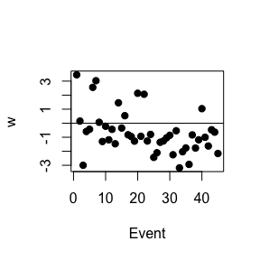

```r
plot(c(res$w), xlab = "Event", ylab = "w", pch = 19)
abline(h = 0)
```

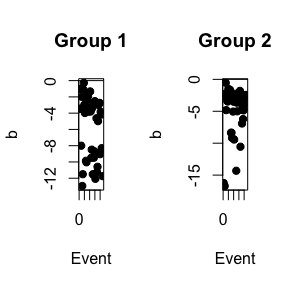

```r
par(mfrow = c(1, 2))

plot(c(res$b[1,]), xlab = "Event", ylab = "b", pch = 19, main = "Group 1")
abline(h = 0)

plot(c(res$b[2,]), xlab = "Event", ylab = "b", pch = 19, main = "Group 2")
abline(h = 0)
```

Plot the probability of each sender node to belong to group 1.

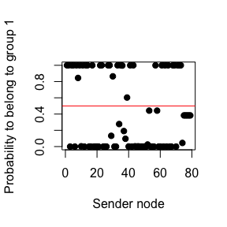

```r
plot(res$z[,1], pch = 19,
  xlab = "Sender node",
  ylab = "Probability to belong to group 1")
abline(h = 0.5, col = "red")
```

Find and plot the probability that the median sender node in group *g* has a link with receiver node *r*.

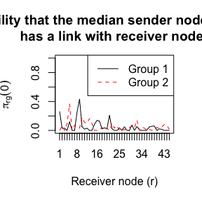

```r
pig0 <- 1 / ( 1 + exp(-res$b))

matplot(t(pig0), type = "l",
  ylim = c(0, 1), ylab = expression(paste(pi[rg](0))),
  xlab = "Receiver node (r)", xaxt = "n",
  main = "Probability that the median sender node in group g\n has a link with receiver node r")
axis(1, at = 1:ncol(X))
legend("topright", paste("Group", 1:2, sep = " "), col = 1:2, lty = 1:2)
```

We can calculate the log-lift for the best model selected.

```r
loglift <- log(lift(res, pdGH = 21))
```

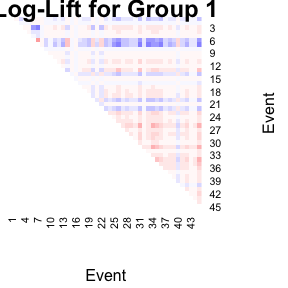

```r
heatmap(
  loglift[,,1],
  Rowv = NA,
  Colv = NA,
  col = colorspace::diverge_hsv(20),
  breaks = seq(-10, 10, by = 1),
  revC = TRUE,
  scale = "none",
  xlab = "Event",
  ylab = "Event",
  main = "Log-Lift for Group 1"
  )
```

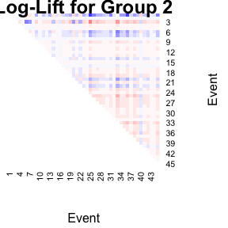

```r
heatmap(
  loglift[,,2],
  Rowv = NA,
  Colv = NA,
  col = colorspace::diverge_hsv(20),
  breaks = seq(-10, 10, by = 1),
  revC = TRUE,
  scale = "none",
  xlab = "Event",
  ylab = "Event",
  main = "Log-Lift for Group 2"
  )
```

### Extra code:

When `D = 0` the `mlta` reduces to the latent class analysis that can be fitted by using `lca`

```r
mod.lca <- lca(X, G = 2:4)
```

When there are no groups (`G = 1`) and `D > 0` the `mlta` reduces to the latent trait analysis that can be fitted by using `lta`

```r
mod.lta <- lta(X, D = 1:3)
```